# **Part Three of the Course Project**

In this project, you will encode movie descriptions into numeric vectors and cluster them using various sets of hyperparameters. You will also search for the hyperparameters that produce the best [`KMeans`](https://scikit-learn.org/stable/modules/generated/sklearn.cluster.KMeans.html) scenario, according to its silhouette score.

# **Setup**

Reset the Python environment to clear it of any previously loaded variables, functions, or libraries. Then, import the libraries and The Movie Database ([TMDB](https://www.themoviedb.org/)) compressed file needed for this project.

```python
%reset -f
from IPython.core.interactiveshell import InteractiveShell as IS
IS.ast_node_interactivity = "all"               # allows multiple outputs from a cell
import pandas as pd, numpy as np, nltk, matplotlib.pyplot as plt, seaborn as sns
import numpy.testing as npt, unittest
from sklearn.cluster import KMeans              # Use ?KMeans to view help documents
from sklearn.metrics import adjusted_rand_score as ARI, silhouette_score as SIL # Use ?silhouette_score to view help documents
from sklearn.decomposition import PCA           # PCA uses SVD to reduce dimensionality of the feature space
from sentence_transformers import SentenceTransformer  # encodes text documents to 768D vectors
from colorunittest import run_unittest
import plotly.graph_objects as go               # import graph object from plotly library
ae, aae = npt.assert_equal, npt.assert_almost_equal

pd.set_option('max_rows', 5, 'max_columns', 40, 'max_colwidth', 100, 'precision', 4) # print format
```

## **Load TMDB File**

In the following setup all movie records are loaded into the `df` dataframe, which is then filtered to largest-budget movies. You will work with only the top 1% of movies (or 49), where [`np.quantile()`](https://numpy.org/doc/stable/reference/generated/numpy.quantile.html) is applied.

One would expect the most expensive movies to either have several high-paid actors, or involve large counts of actors, or be produced over a long period of time, or have lots of fancy graphics. The genres of the selected movies appear to mostly be action, adventures, fantasy, and sci-fi. So, one could expect four large clusters. Here you will build an automatic clustering tool that will identify the clusters based on encoded movie descriptions and interpret these clusters. Having an expectation upfront helps in troubleshooting, in case expectations are not materialized with the clustering output.

```python
df = pd.read_csv('movies.zip').fillna('').set_index('title') # load TMDB database
df = df[df.budget > np.quantile(df.budget, 0.99)]
df.shape
df.iloc[[0]]
```

```
(49, 19)
```

| title | budget | genres | homepage | id | keywords | original_language | original_title | overview | popularity | production_companies | production_countries | release_date | revenue | runtime | spoken_languages | status | tagline | vote_average | vote_count |
| --- | --- | --- | --- | --- | --- | --- | --- | --- | --- | --- | --- | --- | --- | --- | --- | --- | --- | --- | --- |
| Avatar | 237000000 | [{"id": 28, "name": "Action"}, {"id": 12, "name": "Adventure"}, {"id": 14, "name": "Fantasy"}, {... | http://www.avatarmovie.com/ | 19995 | [{"id": 1463, "name": "culture clash"}, {"id": 2964, "name": "future"}, {"id": 3386, "name": "sp... | en | Avatar | In the 22nd century, a paraplegic Marine is dispatched to the moon Pandora on a unique mission, ... | 150.4376 | [{"name": "Ingenious Film Partners", "id": 289}, {"name": "Twentieth Century Fox Film Corporatio... | [{"iso_3166_1": "US", "name": "United States of America"}, {"iso_3166_1": "GB", "name": "United ... | 2009-12-10 | 2787965087 | 162 | [{"iso_639_1": "en", "name": "English"}, {"iso_639_1": "es", "name": "Espa\u00f1ol"}] | Released | Enter the World of Pandora. | 7.2 | 11800 |

## **Task 1**

Next, a [`SBERT`](https://www.sbert.net/) object is defined as a sentence transformer with a pre-trained language model. Your task is to complete the `Encode()` UDF and to embed all movies in its `df` argument. Read the UDF documentation carefully to properly implement this UDF. The output should be a dataframe with as many rows as there are movies in the `df` argument and as many columns as the `SBERT` model defines, i.e., 768 numeric columns in this case. This UDF embeds each movie in a 768-dimensional space. Here is the output of `dfEmb.iloc[:2,:3]`:

| title | 0 | 1 | 2 |
| --- | --- | --- | --- |
| Avatar | 0.2455 | -0.5769 | 0.0374 |
| Pirates of the Caribbean: At World's End | 0.0909 | -0.2742 | -0.1085 |

```python
SBERT = SentenceTransformer('paraphrase-albert-small-v2')  # load a pre-trained language model
```

```python
# COMPLETE THIS CELL
def Encode(df, SBERT=SBERT) -> pd.DataFrame():
    ''' Use SBERT model to encode title, genre, keywords, overview
        concatenated (in that order) via '. '. Wrap the resulting array
        as a dataframe with title as the row label/index.
    Inputs:
        df: TMDB dataframe
        SBERT: loaded sentence transformer model
    Returns: dataframe of encoded movie overviews into 768-dimensional vector space.       '''
    dfEmb = pd.DataFrame(np.zeros((len(df), 768)))  # desired data structure
    text_to_encode = []
    for idx in df.index:
        row = df.loc[idx]
        text = f"{idx}. {row['genres']}. {row['keywords']}. {row['overview']}"
        text_to_encode.append(text)

    encodings = SBERT.encode(text_to_encode, convert_to_numpy=True)
    dfEmb = pd.DataFrame(encodings, index=df.index)


    #raise NotImplementedError()
    return dfEmb

dfEmb = Encode(df)  # define embedding dataframe for the whole TMDB dataframe
dfEmb.iloc[:2,:3]
```

| title | 0 | 1 | 2 |
| --- | --- | --- | --- |
| Avatar | 0.2455 | -0.5769 | 0.0374 |
| Pirates of the Caribbean: At World's End | 0.0909 | -0.2742 | -0.1085 |

```python
# RUN CELL TO TEST YOUR CODE
@run_unittest
class Test_Encode(unittest.TestCase): # class with methods to test functionality of the JS() function
    def test00(self): ae(type(dfEmb[:5]), pd.DataFrame) # must return pandas dataframe
    def test01(self): ae(dfEmb.shape, (49,768)) # must have 49 embeddings of size 768
    def test02(self): ae(list(dfEmb.index[[0,2,6]]), ['Avatar','Spectre','Tangled']) # check index
    def test03(self): aae(dfEmb.iloc[0,:3], [.2455,-.5769,.0374], 4) # few digits in 1st row
    def test04(self): aae(dfEmb.iloc[:3,0], [.2455,.0909,-.4545], 4) # few digits in 1st column
    def test05(self): aae(list(dfEmb.sum())[:3], [-5.3837,-21.7179,-4.3049], 4)
    def test06(self): aae(list(dfEmb.sum(axis=1))[:3], [-5.2841,-2.033,-3.3806], 4)
    def test07(self): aae(dfEmb.sum().sum(), -196.02106, 4)
```

```
Ran 8 tests in 0.016s

OK
test00 (__main__.Test_Encode) ... ok
test01 (__main__.Test_Encode) ... ok
test02 (__main__.Test_Encode) ... ok
test03 (__main__.Test_Encode) ... ok
test04 (__main__.Test_Encode) ... ok
test05 (__main__.Test_Encode) ... ok
test06 (__main__.Test_Encode) ... ok
test07 (__main__.Test_Encode) ... ok

----------------------------------------------------------------------
```

## **Task 2**

In this task you need to complete a `km()` UDF, which takes the movie embeddings, `dfEmb`, and three hyperparameters values: number of clusters `k`, `KMeans` initialization [`init`](https://scikit-learn.org/stable/modules/clustering.html#hierarchical-clustering), and a clustering algorithm `alg`. **(Take note of the instruction below to use random state 0.)** Then it generates movie labels, which identify which cluster (from 0 to `k-1`) each movie belongs to. The predicted labels, `pY`, can be drawn from the `labels_` argument. Here is an output of `km(dfEmb[:10])`:

```
array([0, 0, 0, 1, 0, 0, 1, 0, 1, 1], dtype=int32)
```

```python
# COMPLETE THIS CELL
def km(dfEmb, k=2, init='k-means++', alg='full') -> np.array([bool]):
    '''Builds a trained/fitted hierarchical clustering model from KMeans()
        with the specified k, init and alg parameters. Use random state 0.
    Inputs:
        dfEmb: NxP embeddings table with rows as vectors in P-dimensional space
        k: number of desired clusters
        linkage: type of linkage to use (ward, average, complete, single)
    Returns: a 1D array of N predicted cluster labels
        (in range 0,1,...,k-1), one for each observation      '''
    pY = np.zeros(len(dfEmb))   # desired data structure

    km = KMeans(n_clusters=k, init=init, random_state=0, algorithm=alg)

    km.fit(dfEmb)
    pY = km.labels_

    # YOUR CODE HERE
    #raise NotImplementedError()
    return pY   # predicted cluster labels for the HC algorithm fitted to dfEmb
km(dfEmb, k=2)[:10]
```

```
array([0, 1, 1, 1, 0, 0, 1, 0, 1, 0], dtype=int32)
```

```python
km(dfEmb[:10], k=3) #[1, 0, 1, 2, 1, 1, 0, 2, 0, 2]) # test k
```

```
array([1, 0, 1, 2, 1, 1, 0, 2, 0, 2], dtype=int32)
```

```python
# RUN CELL TO TEST YOUR CODE
@run_unittest
class Test_km(unittest.TestCase): # class with methods to test functionality of the JS() function
    def test00(self): ae(type(km(dfEmb[:5])), np.ndarray) # must return numpy array type
    def test01(self): ae(km(dfEmb[:10]), [0, 0, 0, 1, 0, 0, 1, 0, 1, 1]) # default are 0-1 labels
    def test02(self): ae(km(dfEmb[:10], k=3), [1, 0, 1, 2, 1, 1, 0, 2, 0, 2]) # test k
    def test03(self): ae(km(dfEmb[:10], init='random'), [0, 0, 0, 1, 0, 0, 1, 1, 1, 1]) # test init
    def test04(self): ae(km(dfEmb[:10], alg='elkan'), [0, 0, 0, 1, 0, 0, 1, 0, 1, 1]) # test alg
    def test05(self): ae(km(dfEmb[:10], init='random', alg='elkan'), [0, 0, 0, 1, 0, 0, 1, 1, 1, 1])  # count 1-labels
    def test06(self): ae(km(dfEmb, k=3)[:10], [1, 0, 0, 1, 1, 0, 0, 1, 0, 1]) # fit on ful df; test k
    def test07(self): ae(km(dfEmb, init='random')[:10], [1, 0, 0, 0, 1, 0, 0, 1, 0, 0]) # fit on ful df; test init
    def test08(self): ae(km(dfEmb, alg='elkan')[:10], [0, 1, 1, 1, 0, 0, 1, 0, 1, 0]) # fit on ful df; test alg
    def test09(self): ae(km(dfEmb, init='random', alg='elkan')[:10], [1, 0, 0, 0, 1, 0, 0, 1, 0, 0])  # fit on ful df; test init, alg
    def test06(self): ae(sum(km(dfEmb, k=3)), 32) # fit on ful df; test k on all movies
    def test07(self): ae(sum(km(dfEmb, init='random')), 21) # fit on ful df; test init on all movies
    def test08(self): ae(sum(km(dfEmb, alg='elkan')), 23) # fit on ful df; test alg on all movies
    def test09(self): ae(sum(km(dfEmb, init='random', alg='elkan')), 21)  # fit on ful df; test init/alg on all movies
```

```
Ran 10 tests in 0.536s

OK
test00 (__main__.Test_km) ... ok
test01 (__main__.Test_km) ... ok
test02 (__main__.Test_km) ... ok
test03 (__main__.Test_km) ... ok
test04 (__main__.Test_km) ... ok
test05 (__main__.Test_km) ... ok
test06 (__main__.Test_km) ... ok
test07 (__main__.Test_km) ... ok
test08 (__main__.Test_km) ... ok
test09 (__main__.Test_km) ... ok

----------------------------------------------------------------------
```

## **Task 3**

Here you are tasked with implementing a `sil1()` UDF, which takes embedded movies dataframe, maximum number of clusters, `K`, and returns a dataframe of silhouette scores with the corresponding `k` values. The argument `ReturnBest` indicates whether to keep in dataframe rows with the best (possibly more than one) silhouette scores only. Here is an output of `sil1()`:

| . | SIL | k |
| --- | --- | --- |
| 0 | 0.0755 | 2 |
| 1 | 0.0747 | 3 |

```python
# COMPLETE THIS CELL

#silhouette_score = SIL

def sil1(dfEmb=dfEmb, K=3, ReturnBest=False) -> pd.DataFrame():
    '''Use km() UDF to build and fit K-1 KMeans models with parameter k in the range 2,3,...,K.
    This UDF returns a dataframe with columns SIL (silhouette score) and k (number of clusters).
    If ReturnBest=True, then return (all) rows with the best SIL value.
    If K > number of observations, N, then reset K to N - 1
    Input:
        dfEmb: NxP embedding matrix of P-dimensional row vectors
        K=3: max number of clusters
        ReturnBest: whether result should contain only the rows with the best SIL value
    Return: dataframe dfOut containing columns SIL and k (=2,3,..,K)        '''
    dfOut = pd.DataFrame([[0,0]], columns=['SIL', 'k'])  # desired output structure

    N = len(dfEmb)
    K = min(K, N - 1)

    sil_scores = []

    for k in range(2, K + 1):
        labels = km(dfEmb, k=k)
        sil_score = SIL(dfEmb, labels)
        sil_scores.append({'SIL': sil_score, 'k': k})
    dfOut = pd.DataFrame(sil_scores)

    if ReturnBest:
        best_score = dfOut['SIL'].max()
        dfOut = dfOut[dfOut['SIL'] == best_score]



    return dfOut   # a dataframe with performance for K-1 models

sil1()
```

|  | SIL | k |
| --- | --- | --- |
| 0 | 0.0755 | 2 |
| 1 | 0.0747 | 3 |

```python
# RUN CELL TO TEST YOUR CODE
@run_unittest
class Test_sil1(unittest.TestCase): # class with methods to test functionality of the JS() function
    def test00(self): ae(type(sil1()), pd.DataFrame) # must return a dataframe
    def test01(self): ae(sil1().shape, (2,2))
    def test02(self): ae(list(sil1().columns), ['SIL', 'k'])
    def test03(self): ae(list(sil1().index), [0,1])
    def test04(self): aae(sil1(), [[.07545294, 2],[.07470616, 3]])
    def test05(self): aae(sil1(K=4), [[.0755,2], [.0747,3], [.0519,4]], 3)
    def test06(self): aae(sil1(dfEmb, 4, True).values.tolist(), [[.0755, 2]], 3)
```

```
Ran 7 tests in 2.210s

OK
test00 (__main__.Test_sil1) ... ok
test01 (__main__.Test_sil1) ... ok
test02 (__main__.Test_sil1) ... ok
test03 (__main__.Test_sil1) ... ok
test04 (__main__.Test_sil1) ... ok
test05 (__main__.Test_sil1) ... ok
test06 (__main__.Test_sil1) ... ok

----------------------------------------------------------------------
```

## **Task 4**

Next you will try to reproduce some functionality of SKL's [`GridSearchCV()`](https://scikit-learn.org/stable/modules/generated/sklearn.model_selection.GridSearchCV.html) object which is used to run an estimator (such as `KMeans`) over a set of possible parameters with respect to the given metric. To start you need a list of dictionaries with the desired parameter sets. Then each such dictionary can be passed into `km()` function using [`**`](https://docs.python.org/3/tutorial/controlflow.html#keyword-arguments) argument, which matches each key-value pair in the dictionary with the argument-value of the declared function.

As an example consider a dictionary `par0` below, which contains keys `k`, `init`, and `alg` with their respective values. The same name arguments are declared in function `km()`. So, you can call `km()` with `**par0`, which doesn't pass the dictionary, but passes the key-value pairs of the dictionary. In other words, these two calls are equivalent:

```
km(dfEmb, **par0)
km(dfEmb, k=2, init='k-means++', alg='full')
```

```python
par0 = dict(k=2, init='k-means++', alg='full')
km(dfEmb, **par0)
all(km(dfEmb, **par0) == km(dfEmb, k=2, init='k-means++', alg='full')) # check if Boolean values are equal
```

```
array([0, 1, 1, 1, 0, 0, 1, 0, 1, 0, 0, 1, 1, 0, 0, 1, 0, 1, 0, 1, 0, 1,
       1, 1, 1, 0, 0, 1, 0, 0, 1, 0, 1, 0, 1, 0, 1, 0, 1, 0, 0, 0, 1, 0,
       0, 1, 0, 0, 1], dtype=int32)
```

```
True
```

It's your turn to create a UDF `GenPars()`, which generates a list with elements of `par0`-like dictionaries of parameters for `km()` UDF. Thus, `GenPars()` takes a range of parameters `K`, `inits`, `algs` and generates all possible combinations of these parameters. These combinations are packaged as dictionaries, which are returned in a list (in specific order). Recall that a dictionary stores order-less keys. For example, `GenPars(K=3, inits=['k-means++', 'random'], algs=['full', 'elkan'])` generates the list

```
[{'alg': 'full', 'init': 'k-means++', 'k': 2},
 {'alg': 'elkan', 'init': 'k-means++', 'k': 2},
 {'alg': 'full', 'init': 'random', 'k': 2},
 {'alg': 'elkan', 'init': 'random', 'k': 2},
 {'alg': 'full', 'init': 'k-means++', 'k': 3},
 {'alg': 'elkan', 'init': 'k-means++', 'k': 3},
 {'alg': 'full', 'init': 'random', 'k': 3},
 {'alg': 'elkan', 'init': 'random', 'k': 3}]
```

```python
# COMPLETE THIS CELL
def GenPars(K=3, inits=['k-means++', 'random'], algs=['full', 'elkan']) -> [dict(), ..., dict()]:
    '''Generates a list of dictionaries of the form dict(k=., init=., alg=.),
        where . is the allowed parameter for km(). k values are assumed from 2 to K.
        Thus, all possible combinations of K, init, and alg are packaged as dictionaries.
        Your UDF should cycle first over algs, then over inits, then over 2..K values.
    Inputs:
        K: maximal integer value of k parameter to km(). If K<2 use K=2
        inits: list of allowed KMeans() initializations from a pool ['k-means++', 'random']
        algs: list of allowed values of KMeans() algorithms from a pool ['full', 'elkan']
    Returns: a list of dictionaries of km() hyper-parameters in the form of key-value pairs
    '''
    LDPars = [dict(k=None, init=None, alg=None)]  # list of dictionaries
    # YOUR CODE HERE
    #raise NotImplementedError()
    return LDPars   # a list of dictionaries each containing model hyper-parameters

GenPars(K=3, inits=['k-means++', 'random'], algs=['full', 'elkan'])
```

```
[{'alg': None, 'init': None, 'k': None}]
```

```python
# COMPLETE THIS CELL
def GenPars(K=3, inits=['k-means++', 'random'], algs=['full', 'elkan']) -> [dict(), ..., dict()]:
    '''Generates a list of dictionaries of the form dict(k=., init=., alg=.),
        where . is the allowed parameter for km(). k values are assumed from 2 to K.
        Thus, all possible combinations of K, init, and alg are packaged as dictionaries.
        Your UDF should cycle first over algs, then over inits, then over 2..K values.
    Inputs:
        K: maximal integer value of k parameter to km(). If K<2 use K=2
        inits: list of allowed KMeans() initializations from a pool ['k-means++', 'random']
        algs: list of allowed values of KMeans() algorithms from a pool ['full', 'elkan']
    Returns: a list of dictionaries of km() hyper-parameters in the form of key-value pairs
    '''
    if K < 2:
        K = 2

    LDPars = []

    for k in range(2, K + 1):
        for init in inits:
            for alg in algs:
                LDPars.append({'k': k, 'init': init, 'alg': alg})



    return LDPars   # a list of dictionaries each containing model hyper-parameters

GenPars(K=3, inits=['k-means++', 'random'], algs=['full', 'elkan'])
```

```
[{'alg': 'full', 'init': 'k-means++', 'k': 2},
 {'alg': 'elkan', 'init': 'k-means++', 'k': 2},
 {'alg': 'full', 'init': 'random', 'k': 2},
 {'alg': 'elkan', 'init': 'random', 'k': 2},
 {'alg': 'full', 'init': 'k-means++', 'k': 3},
 {'alg': 'elkan', 'init': 'k-means++', 'k': 3},
 {'alg': 'full', 'init': 'random', 'k': 3},
 {'alg': 'elkan', 'init': 'random', 'k': 3}]
```

```python
[p['init'] for p in GenPars(2)], ['k-means++', 'k-means++', 'random', 'random']
```

```
(['k-means++', 'k-means++', 'random', 'random'],
 ['k-means++', 'k-means++', 'random', 'random'])
```

```python
# RUN CELL TO TEST YOUR CODE
@run_unittest
class Test_GenPars(unittest.TestCase): # class with methods to test functionality of the JS() function
    def test00(self): ae(type(GenPars()), list)
    def test01(self): ae(len(GenPars()), 8)
    def test02(self): ae(GenPars(2, ['k-means++'], ['full']), [{'alg': 'full', 'init': 'k-means++', 'k': 2}])
    def test03(self): ae(GenPars(2, ['random'], ['elkan']), [{'alg': 'elkan', 'init': 'random', 'k': 2}])
    def test04(self): ae(len(GenPars(0, ['k-means++', 'random'], ['full', 'elkan'])), 4) # K<2 should be replaced with 2
    def test05(self): ae([p['k'] for p in GenPars(3)], [2, 2, 2, 2, 3, 3, 3, 3])  # check order of list elements
    def test06(self): ae([p['init'] for p in GenPars(2)], ['k-means++', 'k-means++', 'random', 'random']) # check order of list elements
    def test07(self): ae([p['alg'] for p in GenPars(2)], ['full','elkan']*2) # check order of list elements
```

```
Ran 8 tests in 0.002s

OK
test00 (__main__.Test_GenPars) ... ok
test01 (__main__.Test_GenPars) ... ok
test02 (__main__.Test_GenPars) ... ok
test03 (__main__.Test_GenPars) ... ok
test04 (__main__.Test_GenPars) ... ok
test05 (__main__.Test_GenPars) ... ok
test06 (__main__.Test_GenPars) ... ok
test07 (__main__.Test_GenPars) ... ok

----------------------------------------------------------------------
```

## **Task 5**

Complete `GridSil()` UDF, which applies `km()` to each element (i.e. dictionary of parameters) in the list returned from `GenPars()`. The results are packaged into a dataframe with columns: silhouette score `SIL`, number of clusters `k`, initialization algorithm `init` and k-means algorithm `alg`. For example, `GridSil(pars=GenPars(K=2, inits=['k-means++', 'random'], algs=['full', 'elkan']))` returns (in this order):

| . | SIL | k | init | alg |
| --- | --- | --- | --- | --- |
| 0 | .0755 | 2 | k-means++ | full |
| 1 | .0755 | 2 | k-means++ | elkan |
| 2 | .0622 | 2 | random | full |
| 3 | .0622 | 2 | random | elkan |

```python
# COMPLETE THIS CELL

from sklearn.metrics import silhouette_score



def GridSil(dfEmb=dfEmb, pars=[par0]) -> pd.DataFrame():
    '''Applies km() to movie embedding dataframe dfEmb using parameters in pars.
    Each dictionary in pars results in onw row in dfGrid.
    Inputs:
        dfEmb: movie embedding dataframe with a row per movie and 768 dimensions/columns
        pars: list of parameters (dictionaries) generated by GenPars
    Returns: dfGrid dataframe with silhouette score (SIL) from km() using parameters in each element of pars.     '''
    dfGrid = pd.DataFrame([], columns=['SIL', 'k', 'init', 'alg']) # desired format of returned dataframe
    for param in pars:
        k = param['k']
        init = param['init']
        alg = param['alg']

        km = KMeans(n_clusters=k, init=init, algorithm=alg, random_state=0)
        km.fit(dfEmb)

        labels = km.labels_
        #sil_score = SIL(dfEmb, labels)
        sil_score = silhouette_score(dfEmb, labels)

        dfGrid = dfGrid.append({
            'SIL': sil_score,
            'k': k,
            'init': init,
            'alg': alg
        }, ignore_index=True)


    return dfGrid

pars = GenPars(K=3, inits=['k-means++', 'random'], algs=['full', 'elkan'])
GridSil(pars=pars).style.background_gradient(cmap='coolwarm')
```

|  | SIL | k | init | alg |
| --- | --- | --- | --- | --- |
| 0 | 0.0755 | 2 | k-means++ | full |
| 1 | 0.0755 | 2 | k-means++ | elkan |
| 2 | 0.0622 | 2 | random | full |
| 3 | 0.0622 | 2 | random | elkan |
| 4 | 0.0747 | 3 | k-means++ | full |
| 5 | 0.0747 | 3 | k-means++ | elkan |
| 6 | 0.0671 | 3 | random | full |
| 7 | 0.0671 | 3 | random | elkan |

```python
GridSil(pars=GenPars(K=2, inits=['k-means++', 'random'], algs=['full', 'elkan']))
```

|  | SIL | k | init | alg |
| --- | --- | --- | --- | --- |
| 0 | 0.0755 | 2 | k-means++ | full |
| 1 | 0.0755 | 2 | k-means++ | elkan |
| 2 | 0.0622 | 2 | random | full |
| 3 | 0.0622 | 2 | random | elkan |

```python
from sklearn.metrics import silhouette_score

def SIL(dfEmb, labels):
    '''Calculate the silhouette score for the given embeddings and cluster labels.'''
    return silhouette_score(dfEmb, labels)
```

```python
(GridSil().values.tolist(), [[0.07545293867588043, 2, 'k-means++', 'full']])
```

```
([[0.07545293867588043, 2, 'k-means++', 'full']],
 [[0.07545293867588043, 2, 'k-means++', 'full']])
```

```python
# aae(GridSil(pars=pars8).SIL.tolist(), [0.075, 0.075, 0.062, 0.062, 0.075, 0.075, 0.067, 0.067], 3)
# ae(GridSil(pars=pars8).init.tolist(), ['k-means++', 'k-means++','random', 'random',]*2)
```

```python
# RUN CELL TO TEST YOUR CODE
pars8 = GenPars(K=3, inits=['k-means++', 'random'], algs=['full', 'elkan'])

@run_unittest
class Test_sil2(unittest.TestCase): # class with methods to test functionality of the JS() function
    def test00(self): ae(type(GridSil()), pd.DataFrame)
    def test01(self): ae(list(GridSil().columns), ['SIL', 'k', 'init', 'alg'])
    def test02(self): ae(GridSil(pars=pars).shape, (8,4))
    def test03(self): ae(GridSil().values.tolist(), [[0.07545293867588043, 2, 'k-means++', 'full']])
    def test04(self): aae(GridSil(pars=pars8).SIL.tolist(), [0.075, 0.075, 0.062, 0.062, 0.075, 0.075, 0.067, 0.067], 3)
    def test05(self): aae(GridSil(pars=pars8).k.tolist(), [2, 2, 2, 2, 3, 3, 3, 3], 3)
    def test06(self): ae(GridSil(pars=pars8).init.tolist(), ['k-means++', 'k-means++','random', 'random',]*2)
    def test07(self): ae(GridSil(pars=pars8).alg.tolist(), ['full','elkan']*4)
```

```
Ran 8 tests in 3.225s

OK
test00 (__main__.Test_sil2) ... ok
test01 (__main__.Test_sil2) ... ok
test02 (__main__.Test_sil2) ... ok
test03 (__main__.Test_sil2) ... ok
test04 (__main__.Test_sil2) ... ok
test05 (__main__.Test_sil2) ... ok
test06 (__main__.Test_sil2) ... ok
test07 (__main__.Test_sil2) ... ok

----------------------------------------------------------------------
```

## **Visualization**

Visualization is an important part of machine learning and, if effectively constructed, can help experts make decisions about suitable hyperparameters for the model with the goal of generalizing the model to unseen observations. In the following few cells plots are used to highlight the best silhouette score across numerous hyperparameters.

First, a dataframe of metrics, `dfGS`, is built with with all desired sets of hyperparameters.

```python
pars = GenPars(K=10, inits=['k-means++', 'random'], algs=['full', 'elkan']);
dfGS = GridSil(pars=pars);
dfGS.sort_values('SIL', ascending=False).T
```

|  | 32 | 33 | 28 | 29 | 0 | 1 | 4 | 5 | 24 | 25 | 7 | 6 | 16 | 17 | 3 | 2 | 10 | 11 | 12 | 13 | 9 | 8 | 34 | 35 | 21 | 20 | 19 | 18 | 26 | … |
| --- | --- | --- | --- | --- | --- | --- | --- | --- | --- | --- | --- | --- | --- | --- | --- | --- | --- | --- | --- | --- | --- | --- | --- | --- | --- | --- | --- | --- | --- | --- |
| SIL | 0.07567 | 0.07567 | 0.07547 | 0.07547 | 0.07545 | 0.07545 | 0.07471 | 0.07471 | 0.07 | 0.07 | 0.06711 | 0.06711 | 0.06481 | 0.06481 | 0.06224 | 0.06224 | 0.05817 | 0.05817 | 0.0526 | 0.0526 | 0.05187 | 0.05187 | 0.05012 | 0.05012 | 0.04825 | 0.04825 | 0.04717 | 0.04717 | 0.04688 | … |
| k | 10 | 10 | 9 | 9 | 2 | 2 | 3 | 3 | 8 | 8 | 3 | 3 | 6 | 6 | 2 | 2 | 4 | 4 | 5 | 5 | 4 | 4 | 10 | 10 | 7 | 7 | 6 | 6 | 8 | … |
| init | k-means++ | k-means++ | k-means++ | k-means++ | k-means++ | k-means++ | k-means++ | k-means++ | k-means++ | k-means++ | random | random | k-means++ | k-means++ | random | random | random | random | k-means++ | k-means++ | k-means++ | k-means++ | random | random | k-means++ | k-means++ | random | random | random | … |
| alg | full | elkan | full | elkan | full | elkan | full | elkan | full | elkan | elkan | full | full | elkan | elkan | full | full | elkan | full | elkan | elkan | full | full | elkan | elkan | full | elkan | full | full | … |

The line plot is constructed for each `init` and `alg` combination. Silhouette score, `SIL`, is plotted for each value of `k` (the number of clusters). The highest `SIL` and low complexity (i.e. low `k`) model is preferred. So, we would likely choose `k=2`, `init='k-means++'` and `alg='elkan'` or `alg='full'`. Notably, the algorithm does not affect `SIL` computed on `dfEmb`, so you are observing only the curves laying on top.

Note: The plot shows four curves, but due to the identical values, two lines (orange and red) are plotted on top of the green and blue.

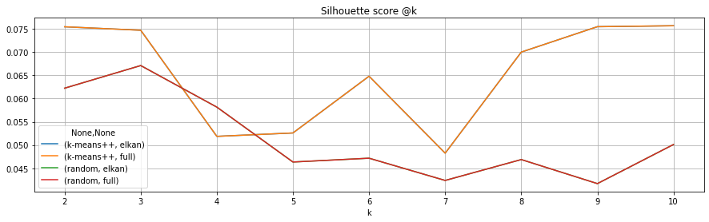

```python
dfGS.set_index('k').groupby(['init','alg'])['SIL'].plot(grid=True,
        figsize=[15,4], legend=True, title='Silhouette score @k');
```

Next, one can visualize clustering with the best set of hyperparameters. To do so with a scatter plot, one needs to represent 768 dimensional points with 2D counterparts. `PCA()` is one popular approach for approximating high dimensional spaces with low dimensional representations. After applying `PCA()` each movie is a 2D point with coordinates $(x,y)$ and a cluster label 0 or 1.

```python
mPC12 = PCA(n_components=2).fit_transform(dfEmb)   # project 768-dim vectors to 2D space for plotting
dfPC12 = pd.DataFrame(mPC12, columns=['x','y'], index=dfEmb.index)
dfPC12['cluster'] = km(dfEmb, k=2, alg='full') # retrieve learnt cluster labels
dfPC12.T                       # contains new (x,y) coordinates and cluster labels
```

| title | Avatar | Pirates of the Caribbean: At World's End | Spectre | The Dark Knight Rises | John Carter | Spider-Man 3 | Tangled | Avengers: Age of Ultron | Harry Potter and the Half-Blood Prince | Batman v Superman: Dawn of Justice | Superman Returns | Quantum of Solace | Pirates of the Caribbean: Dead Man's Chest | The Lone Ranger | Man of Steel | The Chronicles of Narnia: Prince Caspian | The Avengers | Pirates of the Caribbean: On Stranger Tides | Men in Black 3 | The Hobbit: The Battle of the Five Armies | ... | Iron Man 3 | Alice in Wonderland | X-Men: The Last Stand | Monsters University | Transformers: Age of Extinction | Oz: The Great and Powerful | The Amazing Spider-Man 2 | Cars 2 | … |
| --- | --- | --- | --- | --- | --- | --- | --- | --- | --- | --- | --- | --- | --- | --- | --- | --- | --- | --- | --- | --- | --- | --- | --- | --- | --- | --- | --- | --- | --- | --- |
| x | -3.3918 | 4.1562 | -0.3105 | 1.6050 | -3.6614 | -0.6986 | 3.8946 | -3.3779 | 3.5842 | 0.3259 | -3.0182 | 2.2287 | 4.2361 | -2.0997 | -3.3370 | 5.5208 | -4.1030 | 4.2842 | -1.2760 | 3.1767 | ... | -3.3704 | 1.6565 | -2.6229 | 0.2218 | -2.6669 | 1.2569 | -0.7449 | 0.2979 | … |
| y | 1.5036 | 4.5065 | 3.6407 | -3.7375 | -0.0324 | 2.9589 | -2.3444 | -1.3205 | -1.6052 | -2.4344 | -0.9976 | 1.8926 | 3.0819 | 3.5917 | 0.6068 | -1.4160 | 1.0301 | 4.7872 | -2.7818 | 1.5354 | ... | 0.4703 | -0.3854 | -2.1591 | -1.3000 | -1.2898 | -0.8082 | 2.4139 | -1.0929 | … |
| cluster | 0.0000 | 1.0000 | 1.0000 | 1.0000 | 0.0000 | 0.0000 | 1.0000 | 0.0000 | 1.0000 | 0.0000 | 0.0000 | 1.0000 | 1.0000 | 0.0000 | 0.0000 | 1.0000 | 0.0000 | 1.0000 | 0.0000 | 1.0000 | ... | 0.0000 | 1.0000 | 0.0000 | 1.0000 | 0.0000 | 1.0000 | 0.0000 | 1.0000 | … |

3 rows × 49 columns

To represent points in color, one can use RGB strings assigned to each point.

```python
sPlotTtl = 'Clusters Identified by Hierarhichal Clusterning Algorithm'
LsPalette = [f'rgb({c[0]},{c[1]},{c[2]})' for c in sns.color_palette('Set2', max(dfPC12['cluster'])+1)]  # strings of RGB color values
vColors = np.array(LsPalette)[dfPC12.cluster]   # vector of colors (as RGB string) for each point
vColors[:2]
```

```
array(['rgb(0.4,0.7607843137254902,0.6470588235294118)',
       'rgb(0.9882352941176471,0.5529411764705883,0.3843137254901961)'],
      dtype='<U61')
```

Finally, movie representations are plotted in a 2D plot, where you can hover mouse over the points to view their titles. The two clusters are identified in different colors. The left cluster contains mostly superhero and sci-fi movies. On the right side are fantasy and family films.

One can now think whether such clustering makes sense and is desirable. If not, either more descriptive attributes are needed or another model (or model parameters) need to be evaluated.

```python
sMovieGenres = [a + '<br> ' + b for a,b in zip(dfPC12.index, df.tagline)] # point labels with title+genre
DMarkers = dict(size=5, line=dict(width=1, color=vColors), color=vColors)
goMargin = go.layout.Margin(l=0, r=0, b=0, t=0)
goS = go.Scatter(x=dfPC12.x, y=dfPC12.y, mode='markers', marker=DMarkers, text=sMovieGenres);
print(sPlotTtl)
goLayout = go.Layout(hovermode='closest', margin=goMargin, width=1000,
                   height=300, xaxis={'title':'PC1'}, yaxis={'title':'PC2'});

fig = go.Figure(layout=goLayout)  # prepare a figure with specified layout
fig.add_trace(goS)                # add points to canvas
```

```
Clusters Identified by Hierarhichal Clusterning Algorithm
```

[interactive chart not shown]